# read_caliper

## read_caliper

#### Question

1. [Vernier calipers](https://en.wikipedia.org/wiki/Calipers#Vernier_caliper) are cheap devices that allow precise measurements. Let’s practice reading a Vernier caliper.

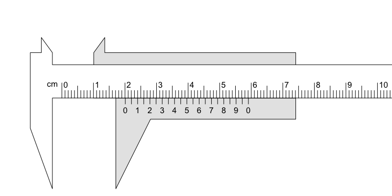

   What is the reading on the calipers? The tolerance is 0.005 cm.

#### Question

2. [Vernier calipers](https://en.wikipedia.org/wiki/Calipers#Vernier_caliper) are cheap devices that allow precise measurements. Let’s practice reading a Vernier caliper.

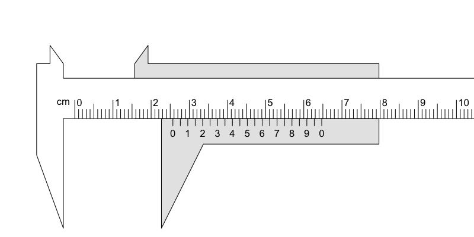

   What is the reading on the calipers? The tolerance is 0.005 cm.

#### Question

3. [Vernier calipers](https://en.wikipedia.org/wiki/Calipers#Vernier_caliper) are cheap devices that allow precise measurements. Let’s practice reading a Vernier caliper.

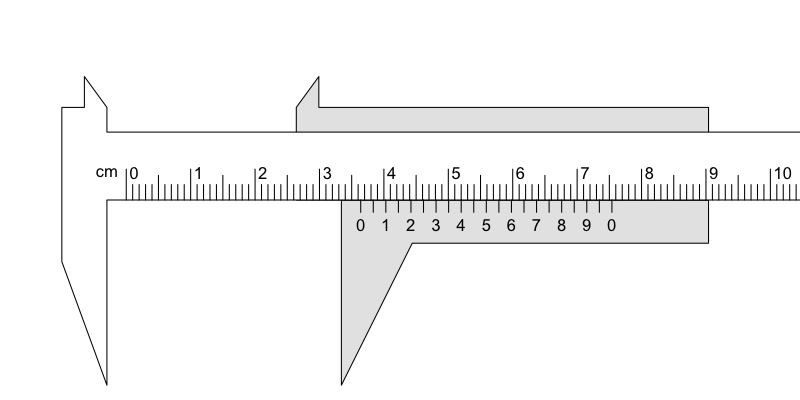

   What is the reading on the calipers? The tolerance is 0.005 cm.

#### Question

4. [Vernier calipers](https://en.wikipedia.org/wiki/Calipers#Vernier_caliper) are cheap devices that allow precise measurements. Let’s practice reading a Vernier caliper.

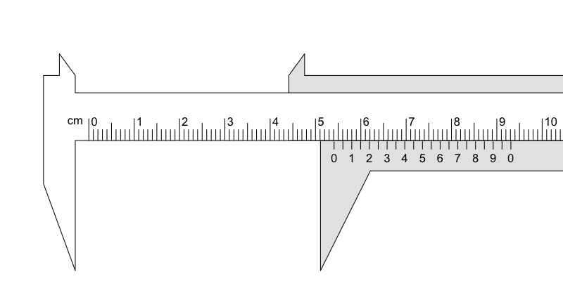

   What is the reading on the calipers? The tolerance is 0.005 cm.

#### Question

5. [Vernier calipers](https://en.wikipedia.org/wiki/Calipers#Vernier_caliper) are cheap devices that allow precise measurements. Let’s practice reading a Vernier caliper.

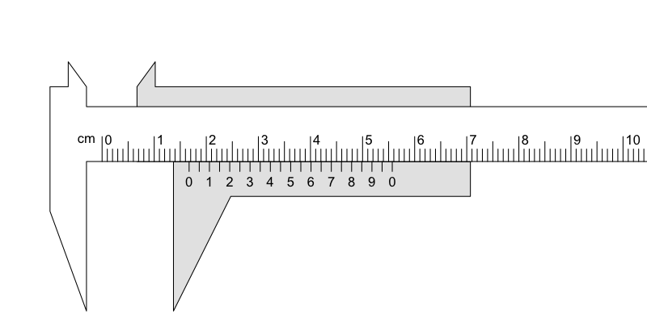

   What is the reading on the calipers? The tolerance is 0.005 cm.

#### Question

6. [Vernier calipers](https://en.wikipedia.org/wiki/Calipers#Vernier_caliper) are cheap devices that allow precise measurements. Let’s practice reading a Vernier caliper.

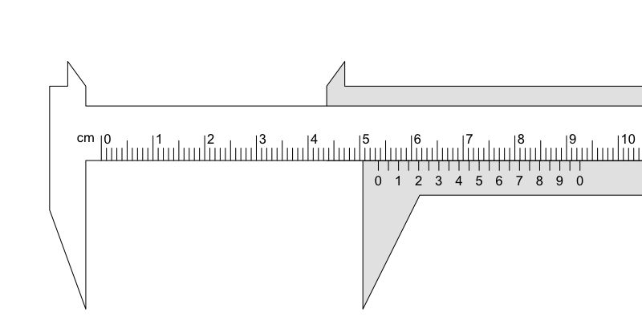

   What is the reading on the calipers? The tolerance is 0.005 cm.

#### Question

7. [Vernier calipers](https://en.wikipedia.org/wiki/Calipers#Vernier_caliper) are cheap devices that allow precise measurements. Let’s practice reading a Vernier caliper.

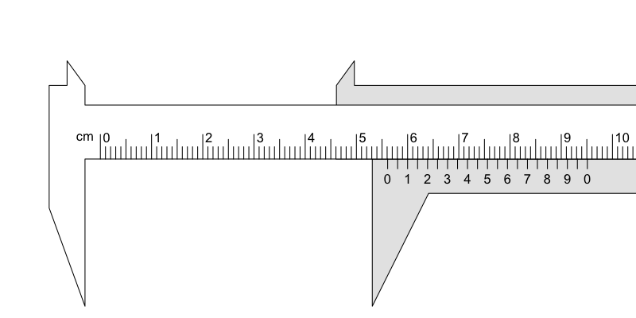

   What is the reading on the calipers? The tolerance is 0.005 cm.

#### Question

8. [Vernier calipers](https://en.wikipedia.org/wiki/Calipers#Vernier_caliper) are cheap devices that allow precise measurements. Let’s practice reading a Vernier caliper.

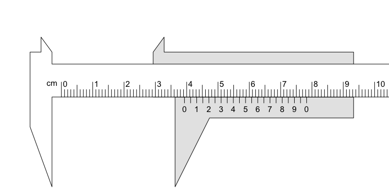

   What is the reading on the calipers? The tolerance is 0.005 cm.